# 10_realistic_daily_combo

Mandy Cheung

2025-09-05

This script creates realistic background conditions, including thermal history and physical environmental conditions of the 3806 reefs of the GBR.

## Load packages

```r
library(tidyverse)
library(sf)
```

```r
library(ggplot2)
library(ozmaps)
library(nngeo)
# base map with QLD
oz_states<-ozmaps::ozmap_states
base_map<-ggplot(oz_states)+
  geom_sf()
```

## Load datasets

Loading the extracted temperature and environmental data for the 3806 reefs from 2011-2023. extracted daily values of environmental parameters that have high variable importance in the random forest model in predicting coral bleaching responses during the Austral summer months between January to March from 2011 to 2023

```r
load("./memory/10_dates_list.RData")

# load temperature data
load("./memory/10_DHW_yearly_3806.RData")
load("./memory/10_histsstsd_3806.RData")
load("./memory/10_histmDHW4_3806.RData")
load("./memory/10_histDHW_mean_3806.RData")
load("./memory/10_yrsinceDHW4_3806.RData")

# load environmental data
load("./memory/10_curr_yearly_3806.RData")
load("./memory/10_Secchi_yearly_3806.RData")
remove(Secchi)
load("./memory/10_clouds_yearly_3806.RData")

# load gbr polygon
load("./memory/01_rfplgn_3806.RData")
gbr_rf_all<-rfplgn_3806
```

## Visual check of data ranges

1. DHW

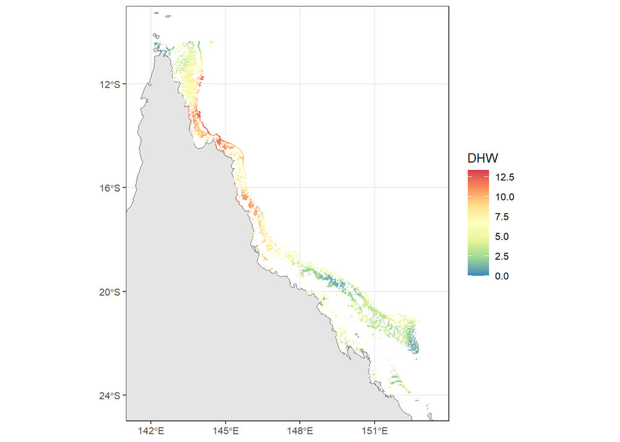

```r
d=7 # year2017
df <- DHW_yearly[[d]] %>% data.frame() %>% dplyr::select(c("ID","X20170331")) %>%
  group_by(ID) %>% summarise(mean=mean(X20170331))
df <- left_join(df, gbr_rf_all, by=c("ID"="rowid"))
df <- st_as_sf(df)
base_map+ df %>%# ggplot() +
  geom_sf(mapping=aes(colour=mean,fill=mean)) +
  scale_colour_distiller(palette = "Spectral", name="DHW")+
  scale_fill_distiller(palette = "Spectral", name="DHW")+
  coord_sf(xlim=c(141,154),ylim=c(-09,-25),expand=FALSE)+
  scale_x_continuous(breaks=c(142,145,148,151)) +
  scale_y_continuous(breaks=c(-12,-16,-20,-24)) +
  theme_bw(base_size=10)
```

2. hist SST SD

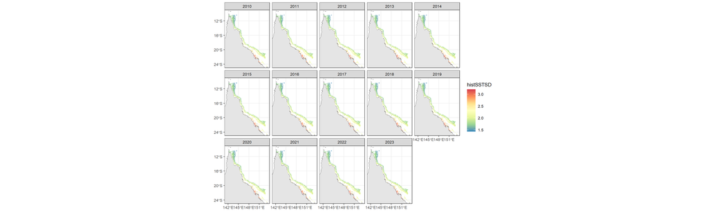

```r
histSST_SD <- left_join(histSST_SD, gbr_rf_all, by=c("rf_ID"="rowid"))
histSST_SD<-st_as_sf(histSST_SD)
base_map+ histSST_SD %>%pivot_longer(cols=c("2010":"2023"), names_to="year", values_to="histSSTSD") %>%
  geom_sf(mapping=aes(colour=histSSTSD,fill=histSSTSD)) +
  facet_wrap(~year, nrow=3)+
  scale_colour_distiller(palette = "Spectral", name="histSSTSD")+
  scale_fill_distiller(palette = "Spectral", name="histSSTSD")+
  coord_sf(xlim=c(141,154),ylim=c(-09,-25),expand=FALSE)+
  scale_x_continuous(breaks=c(142,145,148,151)) +
  scale_y_continuous(breaks=c(-12,-16,-20,-24)) +
  theme_bw(base_size=10)
```

3. mean current rate

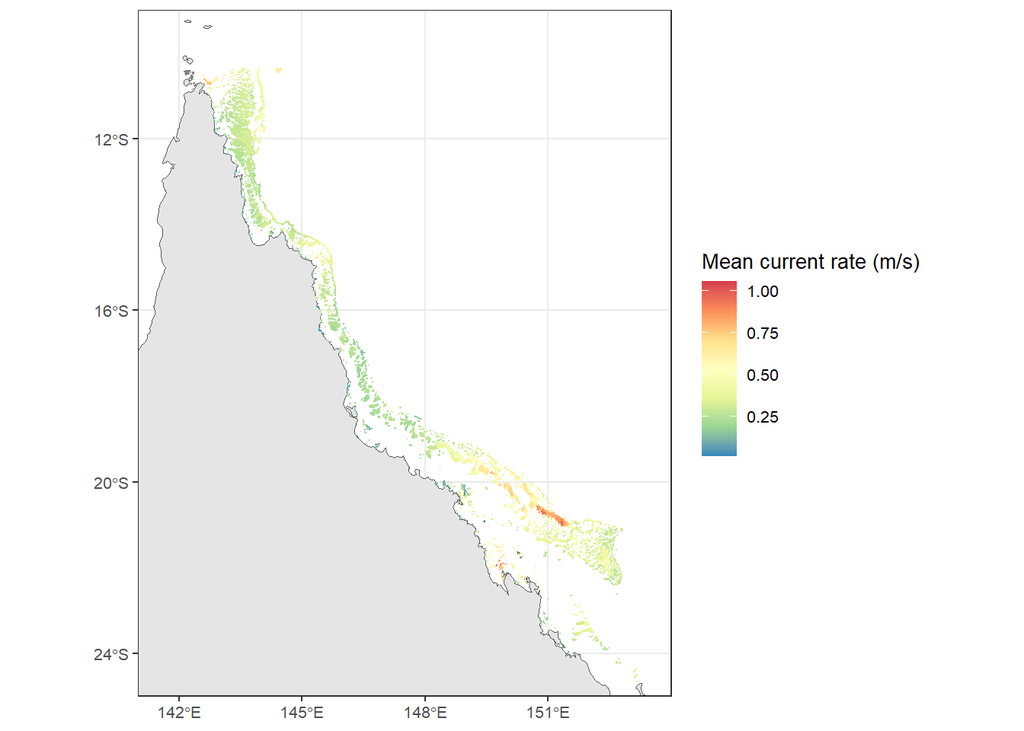

```r
d=5
df <- curr_yearly[[d]] %>% data.frame() %>% dplyr::select(c("ID","X20150330")) %>%
  group_by(ID) %>% summarise(mean=mean(X20150330))
df <- left_join(df, gbr_rf_all, by=c("ID"="rowid"))
df <- st_as_sf(df)
base_map + df %>% # ggplot() +
  geom_sf(mapping=aes(colour=mean,fill=mean)) +
  scale_colour_distiller(palette = "Spectral", name="Mean current rate (m/s)")+
  scale_fill_distiller(palette = "Spectral", name="Mean current rate (m/s)")+
  coord_sf(xlim=c(141,154),ylim=c(-09,-25),expand=FALSE)+
  scale_x_continuous(breaks=c(142,145,148,151)) +
  scale_y_continuous(breaks=c(-12,-16,-20,-24)) +
  theme_bw(base_size=10)
```

(4) mean cloud cover

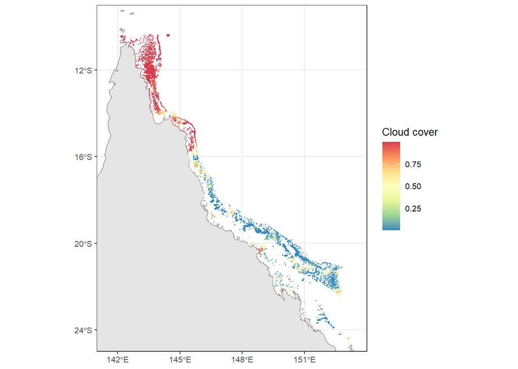

```r
d=6
df <- clouds_yearly[[d]]$"20160215" %>% data.frame()%>%
  group_by(ID) %>% summarise(mean=mean(layer))
df <- left_join(df, gbr_rf_all, by=c("ID"="rowid"))
df <- st_as_sf(df)
base_map + df %>% # ggplot() +
  geom_sf(mapping=aes(colour=mean,fill=mean)) +
  scale_colour_distiller(palette = "Spectral", name="Cloud cover")+
  scale_fill_distiller(palette = "Spectral", name="Cloud cover")+
  coord_sf(xlim=c(141,154),ylim=c(-09,-25),expand=FALSE)+
  scale_x_continuous(breaks=c(142,145,148,151)) +
  scale_y_continuous(breaks=c(-12,-16,-20,-24)) +
  theme_bw(base_size=10)
```

5. secchi depth

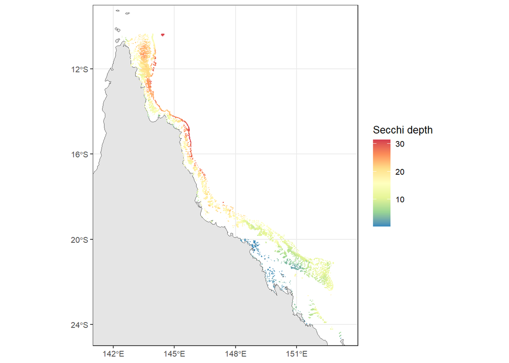

```r
d=7
df<-secchi_yearly[[d]][[1]]$"20170331" %>% data.frame() #%>%
  #group_by(id) %>% summarise(mean=mean(value, na.rm=TRUE))
df$id <- as.numeric(df$id)
df<-rowid_to_column(df)
df<-left_join(df,gbr_spg,by="rowid")
df<-df%>%na.omit()
df$ID <- as.integer(df$ID)
df <- df %>% group_by(LABEL_id) %>% summarise(mean=mean(value))
df <- left_join(df, gbr_rf_all, by=c("LABEL_id"="LABEL_ID"))
df <- st_as_sf(df)

base_map + df %>%# ggplot() +
  geom_sf(mapping=aes(colour=mean,fill=mean)) +
  scale_colour_distiller(palette = "Spectral", name="Secchi depth")+
  scale_fill_distiller(palette = "Spectral", name="Secchi depth")+
  coord_sf(xlim=c(141,154),ylim=c(-09,-25),expand=FALSE)+
  scale_x_continuous(breaks=c(142,145,148,151)) +
  scale_y_continuous(breaks=c(-12,-16,-20,-24)) +
  theme_bw(base_size=10)
```

## Create 20-days mean

First compile the daily mean of the variables for each reef. This part was done only for variables with daily values (including DHW, current, cloud, and secchi depth). Other thermal history variables were summarized at a yearly level, so not needed for this step.

```r
# mean reef level per day
DHWs_yearly<-list()
for (y in 1:length(DHW_yearly)) {
  df<-DHW_yearly[[y]] %>% group_by(ID) %>%
    summarise (across(everything(), mean, na.rm=TRUE))
  DHWs_yearly[[y]] <- df
}

current_yearly<-list()
for (y in 1:length(curr_yearly)){
  df<-curr_yearly[[y]] %>% group_by(ID) %>%
    summarise (across(everything(), mean, na.rm=TRUE))
  current_yearly[[y]]<-df
}

cloud_yearly <- list()
for (y in 1:length(clouds_yearly)) {
  df <- sapply(clouds_yearly[[y]], function(df) {
  tapply(df$layer, df$ID, mean, na.rm = TRUE)
  }) %>% data.frame()
  colnames(df)<-names(clouds_yearly[[y]])
  cloud_yearly[[y]]<-cbind(1:3806, df)
}

secc_yearly <- list()
for (y in 1:length(secchi_yearly)) {
  secc_year=gbr_rf_all[,c("rowid","LABEL_ID")]
  secc_year <- secc_year %>% st_drop_geometry()
  colnames(secc_year)[1:2]<-c("ID","LABEL_ID")
  for (i in 1:length(secchi_yearly[[y]][[1]])){
    if (i<=91){
  df<-secchi_yearly[[y]][[1]][[i]] %>% data.frame() #%>%

  df<-rowid_to_column(df)
  df<-left_join(df,gbr_spg,by="rowid")
  df<-df%>%na.omit()
  df$ID <- as.integer(df$ID)
  df <- df %>% group_by(ID,LABEL_id) %>% summarise(mean=mean(value, na.rm=TRUE))
  colnames(df)[2]<-"LABEL_ID"
  secc_year<-left_join(secc_year,df, by =c("ID","LABEL_ID"))
  colnames(secc_year)[ncol(secc_year)]<-names(secchi_yearly[[y]][[1]][i])
    }
    }
   secc_yearly[[y]]<-secc_year
}

list_of_pred<-list(DHWs_yearly,current_yearly,secc_yearly,cloud_yearly)

save(list_of_pred, DHWs_yearly, current_yearly, secc_yearly, cloud_yearly,
     file="./memory/10_list_of_pred_3806.RData")
```

Because some variables have lots of missing dates, e.g. clouds, in 2019 only 5 dates in March has data. First create a master full date list, to get indices of all dates in all list:

So that the date range covers more dates. This reduces the number of combo from the initial 50 to 30.

```r
combo_values <- list()
counter <- 1

for (y in seq_along(year)) {
 ## so first for each year create a master date list
  master_dates <- names(DHWs_yearly[[y]])[-1] # because DHWs have no missing data
  curr_dates<-data.frame(date=names(current_yearly[[y]])[-1])
  secc_dates<-data.frame(date=names(secc_yearly[[y]])[-1])
  cloud_dates<-data.frame(date=names(cloud_yearly[[y]])[-1])
  master_dates <- data.frame(ID=1:length(master_dates),
                             date=master_dates)
  curr_dates <-curr_dates %>% left_join(., master_dates, by="date")
  secc_dates <- secc_dates %>%  left_join(.,master_dates, by="date")
  cloud_dates <- cloud_dates%>%  left_join(.,master_dates, by="date")

  master_dates<-list(master_dates, curr_dates, secc_dates, cloud_dates)

  # find the minimum index
  lens <- sapply (list_of_pred, function(x) length(x[[y]]))
  which_min<-which.min(lens)

  # create the 30 random start dates, no repeats
  set.seed(random_seed[[y]])
  start_dates <- sample(
    1:((length(list_of_pred[[which_min]][[y]])-1) - 20),
    30,
    replace = FALSE
  )

  # looping through the start dates
  for (i in seq_along(start_dates)) {
    # get the indices of the dates
    ind <- start_dates[i]:(start_dates[i] + 19)
    # calculate the row means for each predictor
    mean_values <- lapply(seq_along(list_of_pred), function(pred_i) {

      df <- list_of_pred[[pred_i]][[y]]

      # Ensure ID column exists
      colnames(df)[1] <- "ID"
      date_ind <- master_dates[[pred_i]] %>% filter(ID %in% (ind)) %>%
        dplyr::select(date) %>%as.vector()
      # # Add missing columns
      missing_cols <- setdiff(date_ind$date, colnames(df))
      if (length(missing_cols) > 0) {
        for (col in missing_cols) {
          df[[col]] <- NA
        }
      }

      # Subset and enforce numeric
      sub_df <- df[, c("ID",date_ind$date)]
      sub_df <- as.data.frame(lapply(sub_df, as.numeric))
      if (anyNA(sub_df)==TRUE){
        sub_df<- left_join(sub_df,rfplgn_3806[,c(8:9,26)], by=c("ID"="rowid"))
        sub_df<-sub_df%>%st_drop_geometry() # drop the polygon and make points for filling
        sub_df<-st_as_sf(sub_df, coords=c("X_COORD","Y_COORD"),crs=4326)
      # Fill NA row-wise
        cols_name <- colnames(sub_df)[2:(ncol(sub_df)-1)]
        sub_df_filled <- fill_nearest_by_day(sub_df, cols_name)
        sub_df_filled <- sub_df_filled %>%st_drop_geometry()
        } else {sub_df_filled <- sub_df}
      # Compute row means
      row_means <- rowMeans(sub_df_filled[,2:ncol(sub_df_filled)], na.rm = TRUE)

      # Convert NaN (all NA rows) -> NA
      row_means[is.nan(row_means)] <- NA

      results <- data.frame(
        ID = df$ID,
        value = row_means
      )

      colnames(results)[2] <- pred_var[pred_i]

      return(results)
    })

    # Join predictors
    mean_values <- purrr::reduce(mean_values, dplyr::left_join, by = "ID")

    mean_values <- data.frame(
      Year = year[y],
      combo = paste0("combo", i),
      mean_values
    )

    combo_values[[counter]] <- mean_values
    counter <- counter + 1
    print(counter)
  }
}

# Combine at the end
combo_values_df <- do.call(rbind, combo_values)


#save(combo_values,combo_values_df, file="./memory/10_env_variable_combo_filled.RData") #15/06/2026 - not used
save(combo_values,combo_values_df, file="./memory/10_env_variable_combo_filled_30.RData") #16/06/2026
```

## Include thermal history data

Because thermal history data were summarized at a yearly level. These will then be static based on the year for each of the 3806 reefs.

```r
# Historical annual SST variability (mean)
histsst_sd <- histSST_SD %>% pivot_longer(cols=c("2011":"2023"), names_to="Year", values_to = "winyear_sd") %>% dplyr::select(-c("2010"))
colnames(histsst_sd)[1]<-"ID"
combo_values_df$Year<-as.character(combo_values_df$Year)
combo_values_df<-left_join(combo_values_df,histsst_sd, by=c("ID","Year"))

# Historical annual max DHW (mean)
histDHW_mean <- histDHW_mean %>% pivot_longer (cols=c("2011":"2023"), names_to="Year", values_to = "histDHW_mean") %>% dplyr::select(-c("2010"))
colnames(histDHW_mean)[1]<-"ID"
combo_values_df<-left_join(combo_values_df,histDHW_mean, by=c("ID", "Year"))

# most recent historical annual max DHW when >= 4
histmDHW4 <- histmDHW4 %>% pivot_longer(cols=c("2011":"2023"), names_to="Year", values_to = "histmDHW4") %>% dplyr::select(-c("2010"))
colnames(histmDHW4)[1]<-"ID"
combo_values_df<-left_join(combo_values_df,histmDHW4, by=c("ID", "Year"))

# year since last exposed to DHW >=4
yrsinceDHW4 <- yrsinceDHW4  %>% pivot_longer(cols=c("2011":"2023"), names_to="Year", values_to = "yrsinceDHW4") %>% dplyr::select(-c("2010"))
colnames(yrsinceDHW4)[1]<-"ID"
combo_values_df<-left_join(combo_values_df,yrsinceDHW4, by=c("ID", "Year"))


combo_values_df<-left_join(combo_values_df, rfplgn_3806[,c(8:9,26)], by=c("ID"="rowid"))
combo_values_df<-combo_values_df%>% st_drop_geometry()
colnames(combo_values_df)[(ncol(combo_values_df)-1):ncol(combo_values_df)]<-c("lon","lat")

anyNA(combo_values_df)


save(combo_values,combo_values_df, file="./memory/10_env_variable_combo_filled_30.RData")
```

Plot as map to check if patterns make sense

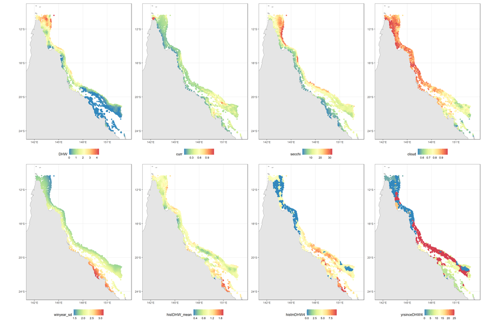

```r
# NAs in curr, secchi, and cloud columns
combo_values_sf<-st_as_sf(combo_values_df, coords=c("lon","lat"), crs=4326)


# because these variables have a different scale, create function to plot individually and patch together
library(patchwork)

plot_sf_patchwork <- function (data, Year_val, combo_val, vars, ncol) {
  plots <- list()
  for (v in vars) {
    p <- base_map+ data %>% filter(Year==Year_val & combo==combo_val) %>%
   geom_sf(mapping=aes(colour=.data[[v]],fill=.data[[v]])) +
  scale_colour_distiller(palette = "Spectral", name=v)+
  scale_fill_distiller(palette = "Spectral", name=v)+
  coord_sf(xlim=c(141,154),ylim=c(-09,-25),expand=FALSE)+
  scale_x_continuous(breaks=c(142,145,148,151)) +
  scale_y_continuous(breaks=c(-12,-16,-20,-24)) +
  theme_bw(base_size=10)  +
      theme(legend.position="bottom")

    plots[[v]]<-p

  }
  wrap_plots(plots, ncol=ncol)
}

## plotting year and combo to check
plot_sf_patchwork(combo_values_sf, Year_val="2011", combo_val="combo1",
                    vars=c("DHW","curr","secchi","cloud","winyear_sd", "histDHW_mean", "histmDHW4","yrsinceDHW4"), ncol=4)
```

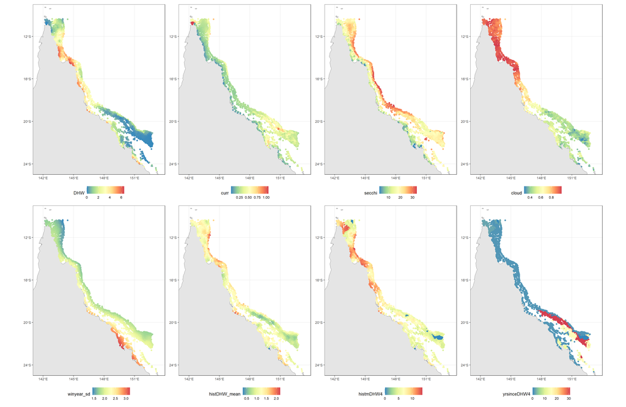

```r
plot_sf_patchwork(combo_values_sf, Year_val="2017", combo_val="combo30",
                    vars=c("DHW","curr","secchi","cloud","winyear_sd", "histDHW_mean", "histmDHW4","yrsinceDHW4"), ncol=4)
```

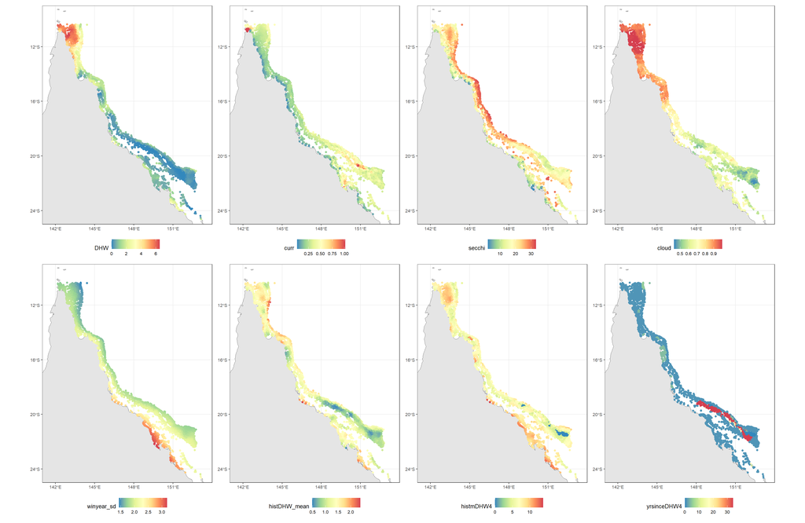

```r
plot_sf_patchwork(combo_values_sf, Year_val="2020", combo_val="combo10",
                    vars=c("DHW","curr","secchi","cloud","winyear_sd", "histDHW_mean", "histmDHW4","yrsinceDHW4"), ncol=4)
```